# Análisis de Sesiones GPS — Monitoreo de Carga Física

Hector Cardenas

2026-05-29

## Introducción

Datos de rastreo GPS de dos sesiones de entrenamiento (MD-3 y MD-4) de un equipo profesional de fútbol. El objetivo es **cuantificar la carga física por posición y tipo de sesión**, identificar a los jugadores más exigentes físicamente y detectar diferencias entre días de entrenamiento — el tipo de información que un Sport Scientist entrega diariamente al cuerpo técnico.

## 1. Librerías y Datos

```r
library(tidyverse)
library(ggrepel)
library(scales)
library(patchwork)
```

```r
data_gps <- read.csv("data/data_gps.csv") %>%
  rename(
    fecha         = Date,
    jugador       = Name,
    sesion        = Session,
    posicion      = Position.Name,
    duracion_min  = Total.Duration,
    distancia_m   = Total.Distance..m.,
    carga_jugador = Total.Player.Load,
    hsr_m         = High.speed.distance..m.,
    hsr_esfuerzos = High.speed.efforts,
    sprint_m      = Sprint.distance..m.,
    sprint_ef     = Sprints.efforts,
    vel_max_kmh   = Maximum.Velocity..km.h.
  ) %>%
  filter(distancia_m > 0) %>%
  mutate(
    carga_por_min = round(carga_jugador / duracion_min, 2),
    ratio_hsr     = round(hsr_m / distancia_m * 100, 1),
    sesion        = factor(sesion, levels = c("MD-4", "MD-3"))
  )

glimpse(data_gps)
```

```
## Rows: 34
## Columns: 15
## $ fecha                   <chr> "2020-06-11", "2020-06-11", "2020-06-11", "202…
## $ jugador                 <chr> "Tatum, Taylor", "Mcmillin, David", "Hunter, A…
## $ sesion                  <fct> MD-4, MD-4, MD-4, MD-4, MD-4, MD-4, MD-4, MD-4…
## $ posicion                <chr> "MEDIA PUNTA", "MEDIO CENTRO", "DELANTERO", "D…
## $ duracion_min            <dbl> 52.6, 52.6, 52.6, 44.8, 52.6, 52.6, 52.6, 52.6…
## $ distancia_m             <int> 3939, 4085, 3841, 2142, 4194, 4220, 4000, 3946…
## $ Total.Acceleration.Load <int> 397, 349, 337, 327, 560, 372, 414, 331, 415, 3…
## $ carga_jugador           <int> 367, 346, 353, 240, 358, 351, 386, 311, 377, 3…
## $ hsr_m                   <int> 139, 183, 166, 105, 154, 199, 150, 94, 184, 16…
## $ hsr_esfuerzos           <int> 6, 15, 13, 7, 10, 15, 10, 5, 14, 13, 3, 7, 10,…
## $ sprint_m                <int> 0, 0, 0, 0, 0, 15, 0, 0, 1, 0, 0, 0, 0, 0, 0, …
## $ sprint_ef               <int> 0, 0, 0, 0, 0, 1, 0, 0, 0, 0, 0, 0, 0, 0, 0, 0…
## $ vel_max_kmh             <dbl> 20.8, 23.2, 23.7, 22.4, 22.2, 25.1, 21.7, 20.4…
## $ carga_por_min           <dbl> 6.98, 6.58, 6.71, 5.36, 6.81, 6.67, 7.34, 5.91…
## $ ratio_hsr               <dbl> 3.5, 4.5, 4.3, 4.9, 3.7, 4.7, 3.8, 2.4, 4.6, 4…
```

## 2. Demanda Física por Posición

Los jugadores en diferentes posiciones cubren distancias distintas y generan cargas diferentes. Comparamos **distancia total**, **carga del jugador** y **carrera de alta velocidad (HSR)** en todas las posiciones.

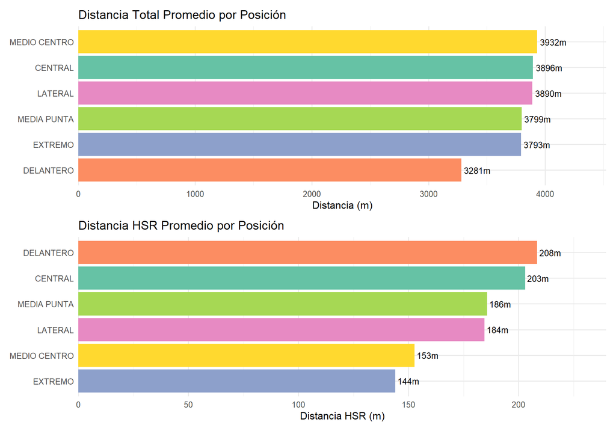

```r
resumen_pos <- data_gps %>%
  group_by(posicion) %>%
  summarise(
    n                = n(),
    prom_distancia   = mean(distancia_m),
    prom_carga       = mean(carga_jugador),
    prom_hsr         = mean(hsr_m),
    prom_vel_max     = mean(vel_max_kmh),
    .groups = "drop"
  ) %>%
  arrange(desc(prom_distancia))

p1 <- ggplot(resumen_pos, aes(x = reorder(posicion, prom_distancia),
                               y = prom_distancia, fill = posicion)) +
  geom_col(show.legend = FALSE) +
  geom_text(aes(label = paste0(round(prom_distancia), "m")), hjust = -0.1, size = 3.5) +
  coord_flip() +
  scale_fill_brewer(palette = "Set2") +
  scale_y_continuous(expand = expansion(mult = c(0, 0.15))) +
  labs(title = "Distancia Total Promedio por Posición", x = NULL, y = "Distancia (m)") +
  theme_minimal(base_size = 12)

p2 <- ggplot(resumen_pos, aes(x = reorder(posicion, prom_hsr),
                               y = prom_hsr, fill = posicion)) +
  geom_col(show.legend = FALSE) +
  geom_text(aes(label = paste0(round(prom_hsr), "m")), hjust = -0.1, size = 3.5) +
  coord_flip() +
  scale_fill_brewer(palette = "Set2") +
  scale_y_continuous(expand = expansion(mult = c(0, 0.15))) +
  labs(title = "Distancia HSR Promedio por Posición", x = NULL, y = "Distancia HSR (m)") +
  theme_minimal(base_size = 12)

p1 / p2
```

## 3. Comparación de Sesiones — MD-4 vs MD-3

A medida que se acerca el día de partido, la intensidad del entrenamiento normalmente aumenta. Verificamos esto con la **carga por minuto** (índice de intensidad) y el **ratio HSR** (% de distancia recorrida a alta velocidad).

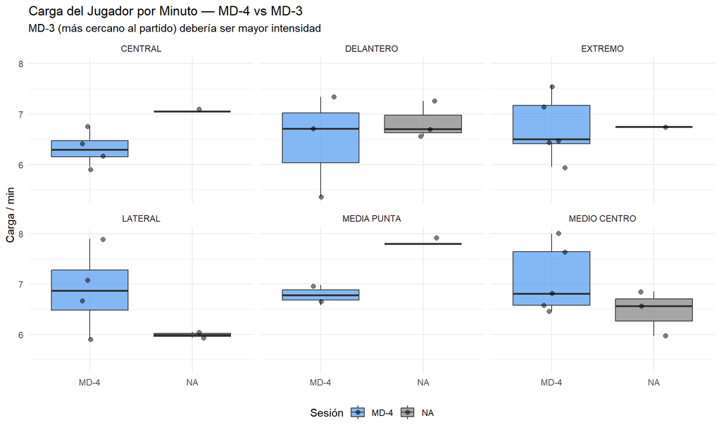

```r
p3 <- ggplot(data_gps, aes(x = sesion, y = carga_por_min, fill = sesion)) +
  geom_boxplot(alpha = 0.7, outlier.shape = 21) +
  geom_jitter(width = 0.15, alpha = 0.5, size = 2) +
  scale_fill_manual(values = c("MD-4" = "#4e9af1", "MD-3" = "#e05c5c")) +
  facet_wrap(~posicion, nrow = 2) +
  labs(
    title    = "Carga del Jugador por Minuto — MD-4 vs MD-3",
    subtitle = "MD-3 (más cercano al partido) debería ser mayor intensidad",
    x = NULL, y = "Carga / min",
    fill = "Sesión"
  ) +
  theme_minimal(base_size = 11) +
  theme(legend.position = "bottom")

p3
```

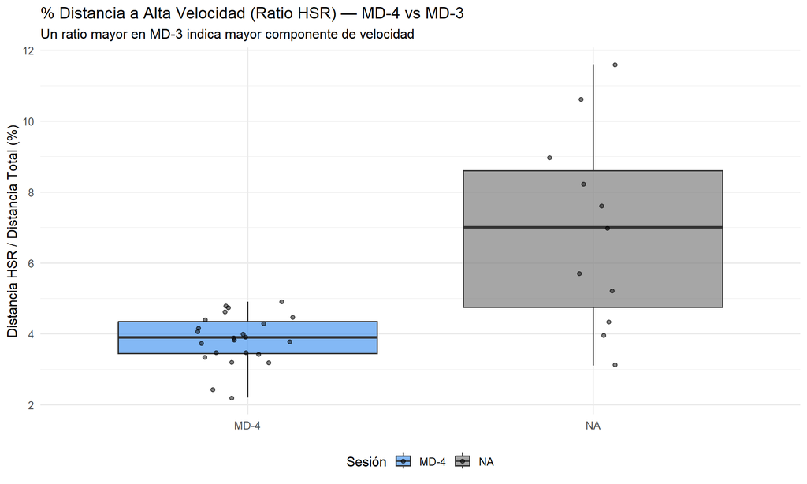

```r
p4 <- ggplot(data_gps, aes(x = sesion, y = ratio_hsr, fill = sesion)) +
  geom_boxplot(alpha = 0.7) +
  geom_jitter(width = 0.15, alpha = 0.5) +
  scale_fill_manual(values = c("MD-4" = "#4e9af1", "MD-3" = "#e05c5c")) +
  labs(
    title    = "% Distancia a Alta Velocidad (Ratio HSR) — MD-4 vs MD-3",
    subtitle = "Un ratio mayor en MD-3 indica mayor componente de velocidad",
    x = NULL, y = "Distancia HSR / Distancia Total (%)",
    fill = "Sesión"
  ) +
  theme_minimal(base_size = 12) +
  theme(legend.position = "bottom")

p4
```

## 4. Ranking Individual de Jugadores

Identificamos quién cubrió más metros y quién fue más explosivo en ambas sesiones combinadas.

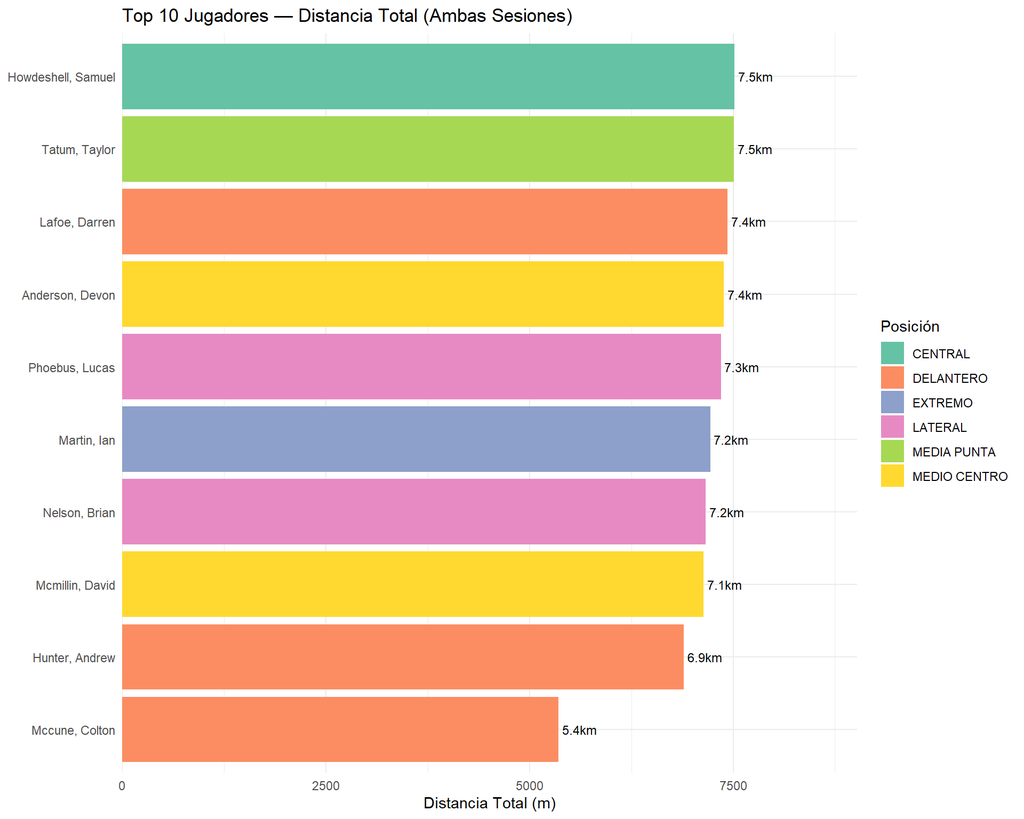

```r
totales_jugador <- data_gps %>%
  group_by(jugador, posicion) %>%
  summarise(
    distancia_total = sum(distancia_m),
    hsr_total       = sum(hsr_m),
    sprints_totales = sum(sprint_ef),
    vel_max_prom    = mean(vel_max_kmh),
    .groups = "drop"
  )

top_distancia <- totales_jugador %>% slice_max(distancia_total, n = 10)

p5 <- ggplot(top_distancia, aes(x = reorder(jugador, distancia_total),
                                 y = distancia_total, fill = posicion)) +
  geom_col() +
  geom_text(aes(label = paste0(round(distancia_total / 1000, 1), "km")),
            hjust = -0.1, size = 3.2) +
  coord_flip() +
  scale_fill_brewer(palette = "Set2") +
  scale_y_continuous(expand = expansion(mult = c(0, 0.2))) +
  labs(
    title = "Top 10 Jugadores — Distancia Total (Ambas Sesiones)",
    x = NULL, y = "Distancia Total (m)", fill = "Posición"
  ) +
  theme_minimal(base_size = 11)

p5
```

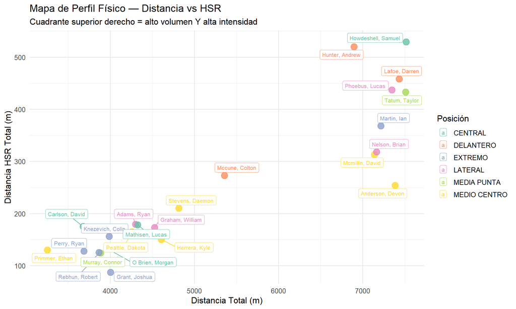

```r
ggplot(totales_jugador, aes(x = distancia_total, y = hsr_total, color = posicion)) +
  geom_point(size = 4, alpha = 0.8) +
  geom_label_repel(aes(label = jugador), size = 2.8, max.overlaps = 12) +
  scale_color_brewer(palette = "Set2") +
  labs(
    title    = "Mapa de Perfil Físico — Distancia vs HSR",
    subtitle = "Cuadrante superior derecho = alto volumen Y alta intensidad",
    x = "Distancia Total (m)", y = "Distancia HSR Total (m)",
    color = "Posición"
  ) +
  theme_minimal(base_size = 12)
```

## 5. Monitoreo por Z-Scores — ¿Quién se desvía de la norma?

Los z-scores normalizan el rendimiento de cada jugador respecto a la media del grupo para esa sesión y posición. Valores por encima de +1.5 o por debajo de -1.5 requieren atención (sobrecarga o bajo rendimiento).

[figure not shown]

```r
z_data <- data_gps %>%
  group_by(sesion, posicion) %>%
  mutate(
    z_distancia = scale(distancia_m)[,1],
    z_carga     = scale(carga_jugador)[,1],
    z_hsr       = scale(hsr_m)[,1]
  ) %>%
  ungroup()

z_largo <- z_data %>%
  select(jugador, sesion, posicion, z_distancia, z_carga, z_hsr) %>%
  pivot_longer(cols = starts_with("z_"), names_to = "metrica", values_to = "z") %>%
  mutate(metrica = recode(metrica,
    z_distancia = "Distancia Total",
    z_carga     = "Carga Jugador",
    z_hsr       = "Distancia HSR"
  ))

ggplot(z_largo %>% filter(sesion == "MD-3"),
       aes(x = metrica, y = reorder(jugador, z), fill = z)) +
  geom_tile(color = "white") +
  geom_text(aes(label = round(z, 1)), size = 3) +
  scale_fill_gradient2(low = "#d73027", mid = "white", high = "#1a9850",
                       midpoint = 0, limits = c(-2.5, 2.5)) +
  labs(
    title    = "Mapa de Calor Z-Score — Sesión MD-3",
    subtitle = "Verde = sobre la media del grupo | Rojo = bajo la media del grupo",
    x = NULL, y = NULL, fill = "Z-Score"
  ) +
  theme_minimal(base_size = 11) +
  theme(axis.text.x = element_text(angle = 20, hjust = 1))
```

## Conclusiones

[output not shown]

*Datos: Sesiones de entrenamiento GPS de equipo profesional de fútbol.* *Análisis: R · tidyverse · ggplot2 · ggrepel · patchwork*